fossil

# Pathway prognosis, dug back up.

We rebuilt the lost pipeline from the paper and reran it on the four public data sets. Of 57 results, 53 were attempted: 0 came back exact, 14 agree, 21 partly, 7 inconclusive and 11 differ.

See every result

## Table 1

Patients and tumours of the four data sets. Counts compared as printed, percentages within one point.

Partly agrees

Table 1, training set (Miller). 39 of 39 values; 6 slips in the paper left out.

| Value | Paper | Ours | Match |
| --- | --- | --- | --- |
| patients | 236 | 236 | yes |
| relapse, count | 55 | 55 | yes |
| relapse, % | 23 | 23.31 | yes |
| non-relapse, count | 181 | 181 | yes |
| non-relapse, % | 77 | 76.69 | yes |
| mean RFS | 8.167 | 8.168 | paper slip |
| mean age | 62.51 | 62.51 | yes |
| ER positive, count | 201 | 201 | yes |
| ER positive, % | 85 | 85.17 | yes |
| ER negative, count | 31 | 31 | yes |
| ER negative, % | 13 | 13.14 | yes |
| ER NA, count | 4 | 4 | yes |
| ER NA, % | 2 | 1.69 | yes |
| PG positive, count | 57 | 179 | paper slip |
| PG positive, % | 24 | 75.85 | paper slip |
| PG negative, count | 179 | 57 | paper slip |
| PG negative, % | 76 | 24.15 | paper slip |
| PG NA | 0 | 0 | yes |
| size <10, count | 13 | 13 | yes |
| size <10, % | 6 | 5.51 | yes |
| size 10-20, count | 92 | 92 | yes |
| size 10-20, % | 40 | 38.98 | paper slip |
| size 20-50, count | 123 | 123 | yes |
| size 20-50, % | 52 | 52.12 | yes |
| size >50, count | 5 | 5 | yes |
| size >50, % | 2 | 2.12 | yes |
| grade 1, count | 62 | 62 | yes |
| grade 1, % | 26 | 26.27 | yes |
| grade 2, count | 121 | 121 | yes |
| grade 2, % | 51 | 51.27 | yes |
| grade 3, count | 51 | 51 | yes |
| grade 3, % | 22 | 21.61 | yes |
| grade NA, count | 2 | 2 | yes |
| grade NA, % | 1 | 0.85 | yes |
| LN positive, count | 78 | 78 | yes |
| LN positive, % | 33 | 33.05 | yes |
| LN negative, count | 149 | 149 | yes |
| LN negative, % | 63 | 63.14 | yes |
| LN NA, count | 9 | 9 | yes |
| LN NA, % | 4 | 3.81 | yes |
| p53 mutated, count | 55 | 55 | yes |
| p53 mutated, % | 23 | 23.31 | yes |
| p53 wild type, count | 181 | 181 | yes |
| p53 wild type, % | 77 | 76.69 | yes |
| p53 NA | 0 | 0 | yes |

Table 1, test set 1 (Pawitan). 14 of 14 values.

| Value | Paper | Ours | Match |
| --- | --- | --- | --- |
| patients | 159 | 159 | yes |
| relapse, count | 40 | 40 | yes |
| relapse, % | 25 | 25.16 | yes |
| non-relapse, count | 119 | 119 | yes |
| non-relapse, % | 75 | 74.84 | yes |
| mean RFS | 5.959 | 5.959 | yes |
| grade 1, count | 28 | 28 | yes |
| grade 1, % | 18 | 17.61 | yes |
| grade 2, count | 58 | 58 | yes |
| grade 2, % | 36 | 36.48 | yes |
| grade 3, count | 61 | 61 | yes |
| grade 3, % | 38 | 38.36 | yes |
| grade NA, count | 12 | 12 | yes |
| grade NA, % | 8 | 7.55 | yes |

Table 1, test set 2 (Ivshina). 37 of 40 values.

| Value | Paper | Ours | Match |
| --- | --- | --- | --- |
| patients | 249 | 249 | yes |
| relapse, count | 89 | 89 | yes |
| relapse, % | 35 | 35.74 | yes |
| non-relapse, count | 160 | 160 | yes |
| non-relapse, % | 64 | 64.26 | yes |
| mean RFS | 7.142 | 7.142 | yes |
| mean age | 62.12 | 62.12 | yes |
| ER positive, count | 211 | 211 | yes |
| ER positive, % | 85 | 84.74 | yes |
| ER negative, count | 34 | 34 | yes |
| ER negative, % | 13 | 13.65 | yes |
| ER NA, count | 4 | 4 | yes |
| ER NA, % | 2 | 1.61 | yes |
| size <10, count | 14 | 15 | no |
| size <10, % | 6 | 6.02 | yes |
| size 10-20, count | 95 | 95 | yes |
| size 10-20, % | 38 | 38.15 | yes |
| size 20-50, count | 129 | 129 | yes |
| size 20-50, % | 52 | 51.81 | yes |
| size >50, count | 10 | 6 | no |
| size >50, % | 4 | 2.41 | no |
| grade 1, count | 68 | 68 | yes |
| grade 1, % | 27 | 27.31 | yes |
| grade 2, count | 126 | 126 | yes |
| grade 2, % | 51 | 50.6 | yes |
| grade 3, count | 55 | 55 | yes |
| grade 3, % | 22 | 22.09 | yes |
| grade NA | 0 | 0 | yes |
| LN positive, count | 81 | 81 | yes |
| LN positive, % | 32 | 32.53 | yes |
| LN negative, count | 159 | 159 | yes |
| LN negative, % | 64 | 63.86 | yes |
| LN NA, count | 9 | 9 | yes |
| LN NA, % | 4 | 3.61 | yes |
| p53 mutated, count | 58 | 58 | yes |
| p53 mutated, % | 23 | 23.29 | yes |
| p53 wild type, count | 189 | 189 | yes |
| p53 wild type, % | 76 | 75.9 | yes |
| p53 NA, count | 2 | 2 | yes |
| p53 NA, % | 1 | 0.8 | yes |

Table 1, test set 3 (Desmedt). 29 of 30 values.

| Value | Paper | Ours | Match |
| --- | --- | --- | --- |
| patients | 198 | 198 | yes |
| relapse, count | 91 | 91 | yes |
| relapse, % | 46 | 45.96 | yes |
| non-relapse, count | 107 | 107 | yes |
| non-relapse, % | 54 | 54.04 | yes |
| mean RFS | 9.312 | 9.312 | yes |
| mean age | 46.39 | 46.39 | yes |
| ER positive, count | 134 | 134 | yes |
| ER positive, % | 67 | 67.68 | yes |
| ER negative, count | 64 | 64 | yes |
| ER negative, % | 33 | 32.32 | yes |
| ER NA | 0 | 0 | yes |
| size <10, count | 9 | 9 | yes |
| size <10, % | 4 | 4.55 | yes |
| size 10-20, count | 59 | 59 | yes |
| size 10-20, % | 30 | 29.8 | yes |
| size 20-50, count | 129 | 129 | yes |
| size 20-50, % | 65 | 65.15 | yes |
| size >50, count | 1 | 0 | no |
| size >50, % | 1 | 0.0 | yes |
| grade 1, count | 30 | 30 | yes |
| grade 1, % | 15 | 15.15 | yes |
| grade 2, count | 83 | 83 | yes |
| grade 2, % | 42 | 41.92 | yes |
| grade 3, count | 83 | 83 | yes |
| grade 3, % | 42 | 41.92 | yes |
| grade NA, count | 2 | 2 | yes |
| grade NA, % | 1 | 1.01 | yes |
| LN negative, count | 198 | 198 | yes |
| LN negative, % | 100 | 100.0 | yes |

**Table 1, training set (Miller)**

39 of 39 values; 6 slips in the paper left out, Agrees

**Table 1, test set 1 (Pawitan)**

14 of 14 values, Agrees

**Table 1, test set 2 (Ivshina)**

37 of 40 values, Partly agrees

**Table 1, test set 3 (Desmedt)**

29 of 30 values, Partly agrees

The size classes' boundaries are not given. Counting 50 mm tumours as over 50 gives the paper's 10 (strictly over 50: 6); under 10 mm gives 15 against the printed 14 with any boundary we tried. The largest Desmedt tumour is 50 mm; the paper's one tumour over 50 mm is it, counted as over 50 (as for Ivshina; Miller's three 50 mm tumours are in no class).

## Fig. 1

The training set (Miller): PAM50 heatmap and Kaplan-Meier curves by lymph node status, grade, p53 status and tumour size.

Differs

Published

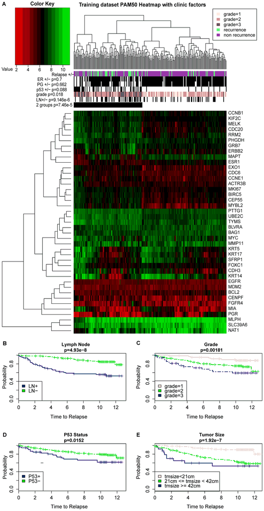

Our run

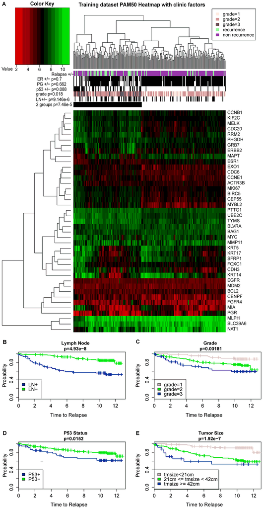

**Fig. 1A, chi-square p of ER, PG, p53, grade and LN against relapse (Miller)**

5 of 5 values, Agrees

**Fig. 1A and text, chi-square p of the two PAM50 clusters against relapse**

0 of 1 values, Differs

**Fig. 1B to E and text, log-rank p of LN, grade, p53, size, ER and PG (Miller)**

6 of 6 values, Agrees

**Fig. 1B, Kaplan-Meier by lymph node status**

97.9% of curve pixels within 2 px (pass 90.0%, best control 78.7%), Agrees

**Fig. 1C, Kaplan-Meier by grade**

96.2% of curve pixels within 2 px (pass 90.0%, best control 77.6%), Agrees

**Fig. 1D, Kaplan-Meier by p53 status**

98.4% of curve pixels within 2 px (pass 90.0%, best control 79.7%), Agrees

**Fig. 1E, Kaplan-Meier by tumour size**

96.7% of curve pixels within 2 px (pass 90.0%, best control 77.1%), Agrees

No clustering of the Miller tumours on the PAM50 genes we tried reaches the printed p (best 0.011 against 7.46e-5); the paper does not say how it clustered or which PAM50 genes it used (41 of 50 are on our gene list).

## Table 2

Features of the genomic and clinical models, and the univariate Cox p-values.

Partly agrees

Table 2, pathway-based genomic model: pathways and coefficients. 3 of 30 values.

| Value | Paper | Ours | Match |
| --- | --- | --- | --- |
| KEGG_MELANOGENESIS selected | yes | no | no |
| KEGG_MELANOGENESIS coefficient | 1.075908 | 0.0 | no |
| BIOCARTA_SRCRPTP_PATHWAY selected | yes | yes | yes |
| BIOCARTA_SRCRPTP_PATHWAY coefficient | 0.914698 | 1.51892 | no |
| BIOCARTA_AKAP13_PATHWAY selected | yes | no | no |
| BIOCARTA_AKAP13_PATHWAY coefficient | 0.828364 | 0.0 | no |
| BIOCARTA_RARRXR_PATHWAY selected | yes | yes | yes |
| BIOCARTA_RARRXR_PATHWAY coefficient | 0.670795 | 0.677266 | no |
| BIOCARTA_VIP_PATHWAY selected | yes | no | no |
| BIOCARTA_VIP_PATHWAY coefficient | 0.635108 | 0.0 | no |
| KEGG_FATTY_ACID_METABOLISM selected | yes | no | no |
| KEGG_FATTY_ACID_METABOLISM coefficient | 0.520653 | 0.0 | no |
| BIOCARTA_G1_PATHWAY selected | yes | no | no |
| BIOCARTA_G1_PATHWAY coefficient | 0.520446 | 0.0 | no |
| KEGG_LINOLEIC_ACID_METABOLISM selected | yes | no | no |
| KEGG_LINOLEIC_ACID_METABOLISM coefficient | 0.368615 | 0.0 | no |
| KEGG_LYSOSOME selected | yes | no | no |
| KEGG_LYSOSOME coefficient | 0.300587 | 0.0 | no |
| BIOCARTA_P53_PATHWAY selected | yes | no | no |
| BIOCARTA_P53_PATHWAY coefficient | 0.239062 | 0.0 | no |
| BIOCARTA_PYK2_PATHWAY selected | yes | no | no |
| BIOCARTA_PYK2_PATHWAY coefficient | 0.158405 | 0.0 | no |
| BIOCARTA_GABA_PATHWAY selected | yes | no | no |
| BIOCARTA_GABA_PATHWAY coefficient | 0.139229 | 0.0 | no |
| BIOCARTA_FEEDER_PATHWAY selected | yes | no | no |
| BIOCARTA_FEEDER_PATHWAY coefficient | 0.110334 | 0.0 | no |
| BIOCARTA_RNA_PATHWAY selected | yes | no | no |
| BIOCARTA_RNA_PATHWAY coefficient | 0.037978 | 0.0 | no |
| BIOCARTA_IL5_PATHWAY selected | yes | yes | yes |
| BIOCARTA_IL5_PATHWAY coefficient | 0.012039 | -0.106275 | no |

Table 2, univariate Cox p of the 15 pathways on our scores. 4 of 15 values.

| Value | Paper | Ours | Match |
| --- | --- | --- | --- |
| KEGG_MELANOGENESIS univariate p (-log10) | 2.7258 | 0.4881 | no |
| BIOCARTA_SRCRPTP_PATHWAY univariate p (-log10) | 6.9957 | 6.2416 | yes |
| BIOCARTA_AKAP13_PATHWAY univariate p (-log10) | 2.4547 | 0.1596 | no |
| BIOCARTA_RARRXR_PATHWAY univariate p (-log10) | 5.0186 | 3.1817 | no |
| BIOCARTA_VIP_PATHWAY univariate p (-log10) | 4.6676 | 0.1051 | no |
| KEGG_FATTY_ACID_METABOLISM univariate p (-log10) | 5.5969 | 2.4611 | no |
| BIOCARTA_G1_PATHWAY univariate p (-log10) | 5.5751 | 1.9081 | no |
| KEGG_LINOLEIC_ACID_METABOLISM univariate p (-log10) | 3.4498 | 0.1232 | no |
| KEGG_LYSOSOME univariate p (-log10) | 5.6576 | 0.2661 | no |
| BIOCARTA_P53_PATHWAY univariate p (-log10) | 3.0585 | 2.7578 | yes |
| BIOCARTA_PYK2_PATHWAY univariate p (-log10) | 3.8894 | 0.4393 | no |
| BIOCARTA_GABA_PATHWAY univariate p (-log10) | 1.7905 | 0.0107 | no |
| BIOCARTA_FEEDER_PATHWAY univariate p (-log10) | 1.6615 | 1.1764 | yes |
| BIOCARTA_RNA_PATHWAY univariate p (-log10) | 4.1152 | 2.5646 | no |
| BIOCARTA_IL5_PATHWAY univariate p (-log10) | 2.0482 | 2.9496 | yes |

Table 2, clinical model: features and coefficients. 5 of 9 values.

| Value | Paper | Ours | Match |
| --- | --- | --- | --- |
| node selected | yes | yes | yes |
| node coefficient | 0.375874 | 0.424421 | no |
| size_mm selected | yes | yes | yes |
| size_mm coefficient | 0.270893 | 0.270618 | no |
| grade selected | yes | yes | yes |
| grade coefficient | 0.126814 | 0.119845 | no |
| p53 selected | yes | yes | yes |
| p53 coefficient | 0.043517 | 0.0536025 | no |
| other features selected | none | none | yes |

Table 2, univariate Cox p of LN, size, grade and p53. 4 of 4 values.

| Value | Paper | Ours | Match |
| --- | --- | --- | --- |
| LN | 4.46e-7 | 4.46336e-07 | yes |
| size | 6.03e-7 | 6.02764e-07 | yes |
| grade | 4.92e-4 | 0.000491789 | yes |
| p53 | 0.0171 | 0.0171205 | yes |

Table 2 and text, combined model: pathways kept and clinical features. 4 of 5 values.

| Value | Paper | Ours | Match |
| --- | --- | --- | --- |
| genomic-model pathways kept | 10 | 4 | no |
| lymph node selected | yes | yes | yes |
| tumour size selected | yes | yes | yes |
| grade selected | no | no | yes |
| p53 selected | no | no | yes |

**Table 2, pathway-based genomic model: pathways and coefficients**

3 of 30 values, Partly agrees

**Table 2, univariate Cox p of the 15 pathways on our scores**

4 of 15 values, Partly agrees

**Table 2, clinical model: features and coefficients**

5 of 9 values, Partly agrees

**Table 2, univariate Cox p of LN, size, grade and p53**

4 of 4 values, Agrees

**Table 2 and text, combined model: pathways kept and clinical features**

4 of 5 values, Partly agrees

Our LASSO keeps 5 pathways, 3 of them the paper's (SRCRPTP, RARRXR, IL5); the paper keeps 15. The selection follows from the scores, and our scores of the paper's pathways are not the paper's (table2.genomic_univariate). The paper's coefficients applied to our scores give Miller p 2.3e-4 and AUC 0.66 (printed 6.25e-12 and 0.80). Our pathway scores are not the paper's: of the 15 pathways of Table 2, 4 have a univariate Cox p within one order of magnitude of the printed one on our scores, and VIP, LYSOSOME, AKAP13 and LINOLEIC ACID, printed p 2e-6 to 4e-3, have p 0.5 to 0.8. pathifier is deterministic here (seeds 1 to 3 give the same scores), and no preprocessing variant we tried brings these pathways back. The paper's pathifier run, gene mapping and MSigDB release are not available. The same four features are selected; the coefficients differ by 0.0003 to 0.049. The penalty is the median of 250 random cross-validations (ours 7.32); its exact value depends on the folds, which the paper does not give. Lymph node and size are kept and grade and p53 are not, as in the paper; 4 of our 5 genomic pathways are kept (paper: 10 of 15). The pathway count follows from our genomic model (table2.genomic).

## Fig. 4

The pathway-based genomic model, trained on Miller and cut at its 3rd quartile, on the four data sets; ROC curves.

Inconclusive

Published

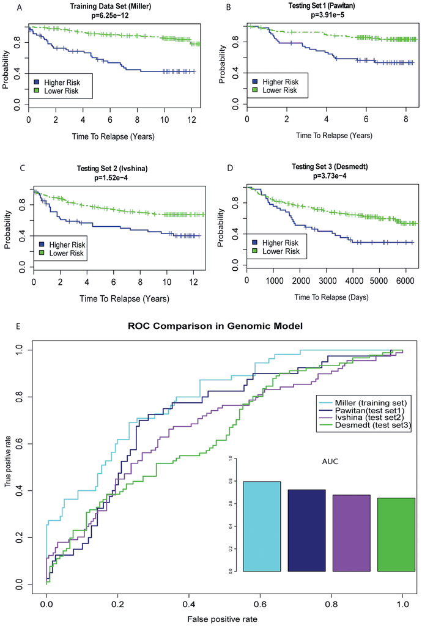

Our run

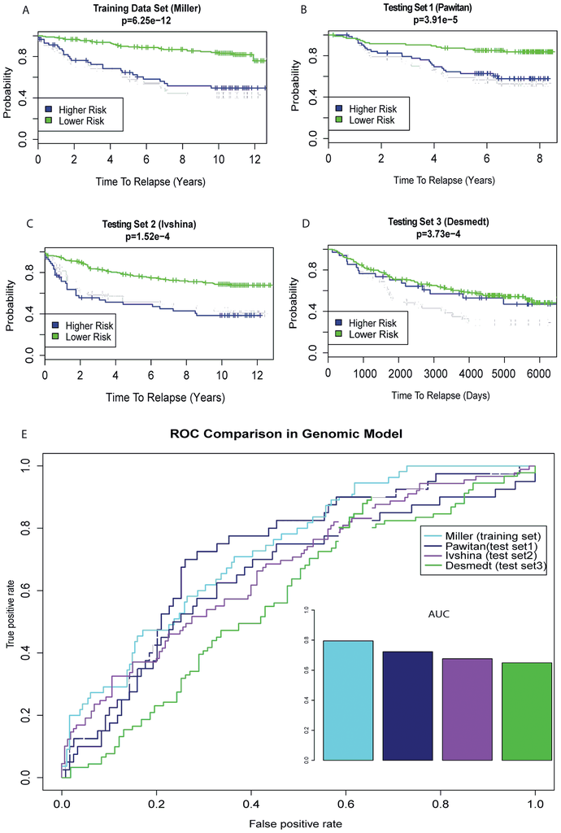

**Fig. 4 and text, log-rank p and AUC of the genomic model on the four sets**

1 of 8 values, Partly agrees

**Fig. 4A, training set (Miller)**

36.8% of curve pixels within 2 px (pass 90.0%, best control 33.6%), Partly agrees

**Fig. 4B, test set 1 (Pawitan)**

47.0% of curve pixels within 2 px (pass 90.0%, best control 43.1%), Partly agrees

**Fig. 4C, test set 2 (Ivshina)**

39.7% of curve pixels within 2 px (pass 90.0%, best control 35.1%), Partly agrees

**Fig. 4D, test set 3 (Desmedt)**

13.6% of curve pixels within 2 px (pass 90.0%, best control 24.8%), Inconclusive

**Fig. 4E, ROC curves of the genomic model**

10.0% of curve pixels within 2 px (pass 90.0%, best control 8.8%), Partly agrees

The models are fitted on our pathway scores, which are not the paper's (table2.genomic_univariate): our genomic model keeps 5 pathways, not 15. It reaches Miller p 1.1e-7 and AUC 0.73 (printed 6.25e-12, 0.80), Pawitan 5.4e-4 (3.91e-5), Ivshina 1.9e-6 (1.52e-4) and Desmedt 0.69 (3.73e-4); Ivshina's AUC is the paper's. Ivshina is not an independent test set: 232 of its 249 arrays are Miller's (GSE4922 re-deposits GSE3494's arrays), which may be why it is the only test set where we do better than printed. The curves follow our model, not the paper's; see fig4.values.

## Fig. 5

Gene-based against pathway-based models, each trained on its own data set.

Differs

Published

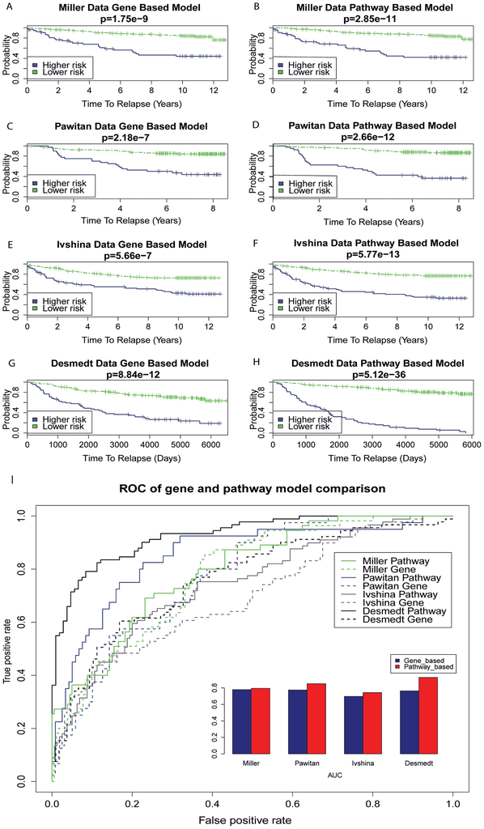

Our run

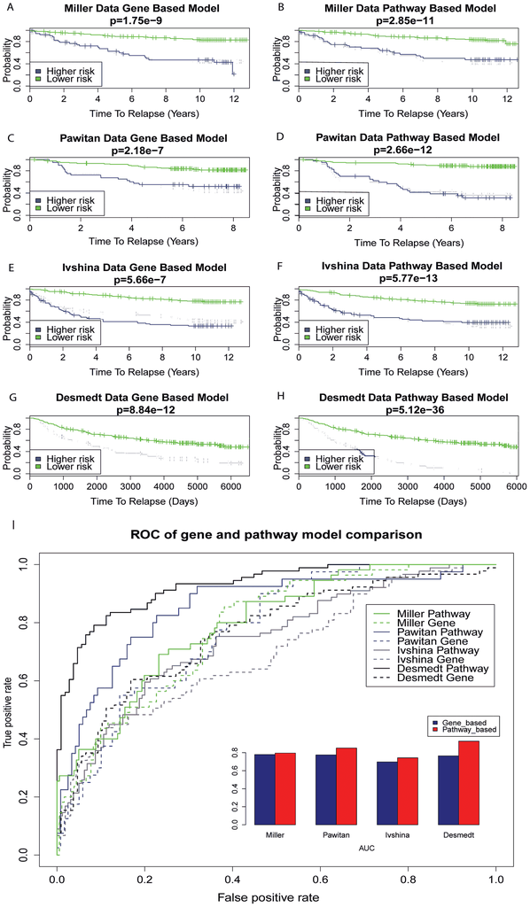

**Fig. 5 and text, log-rank p and AUC of the gene- and pathway-based models**

2 of 16 values, Partly agrees

**Fig. 5A, Miller gene-based model**

72.3% of curve pixels within 2 px (pass 90.0%, best control 74.7%), Inconclusive

**Fig. 5B, Miller pathway-based model**

56.8% of curve pixels within 2 px (pass 90.0%, best control 57.3%), Inconclusive

**Fig. 5C, Pawitan gene-based model**

56.0% of curve pixels within 2 px (pass 90.0%, best control 49.7%), Partly agrees

**Fig. 5D, Pawitan pathway-based model**

55.9% of curve pixels within 2 px (pass 90.0%, best control 50.9%), Partly agrees

**Fig. 5E, Ivshina gene-based model**

15.0% of curve pixels within 2 px (pass 90.0%, best control 45.1%), Inconclusive

**Fig. 5F, Ivshina pathway-based model**

53.6% of curve pixels within 2 px (pass 90.0%, best control 52.6%), Partly agrees

**Fig. 5G, Desmedt gene-based model**

0.7% of curve pixels within 2 px (pass 90.0%, best control 6.6%), Differs

**Fig. 5H, Desmedt pathway-based model**

0.9% of curve pixels within 2 px (pass 90.0%, best control 26.1%), Differs

**Text: pathway-based models beat gene-based models on all four sets**

pathway-based better than gene-based (lower p and higher AUC) in 1 of 4 sets: pawitan, Differs

The pathway models are fitted on our pathway scores, which are not the paper's (table2.genomic_univariate); the gene models on our gene-level expression, whose mapping and normalization may differ from the paper's (biomaRt through RefSeq, CONOR), so Pawitan's and Ivshina's gene models differ too. Desmedt has almost no relapse signal in our hands: no pathway has univariate p below 0.008 and no gene below 3.4e-5 (of 7,455 expressed), so cross-validation picks a penalty (pathways 4.7 to 6.2, genes 47 to 79) that keeps nothing and both Desmedt models are empty. The paper's Desmedt pathway result (p 5.12e-36, AUC 0.92 on 198 patients) is close to what a penalty near 1 gives in-sample: 77 pathways, p 2.8e-37, AUC 0.94. The curves follow our model, not the paper's; see fig5.values. On our scores the pathway model beats the gene model on Pawitan only; on Miller it has the higher AUC but the higher p, on Ivshina the gene model wins, and on Desmedt neither model keeps a feature. See fig5.values.

## Fig. 6

Genomic, combined and clinical models on Miller and Ivshina.

Differs

Published

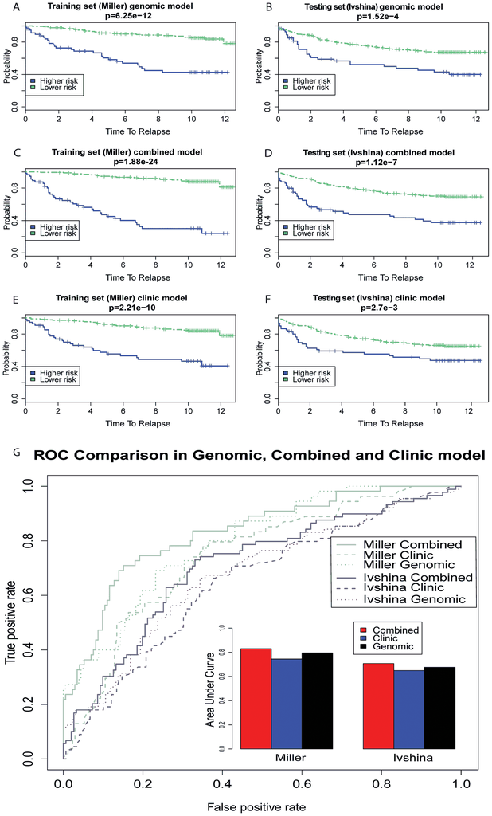

Our run

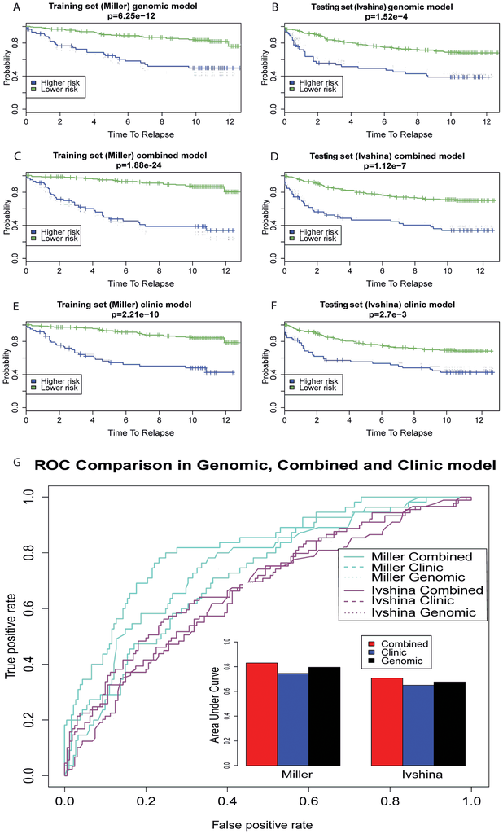

**Fig. 6 and text, log-rank p and AUC of the genomic, combined and clinical models**

6 of 12 values, Partly agrees

**Fig. 6A, Miller genomic model**

37.6% of curve pixels within 2 px (pass 90.0%, best control 33.6%), Partly agrees

**Fig. 6B, Ivshina genomic model**

35.5% of curve pixels within 2 px (pass 90.0%, best control 32.3%), Partly agrees

**Fig. 6C, Miller combined model**

43.7% of curve pixels within 2 px (pass 90.0%, best control 38.0%), Partly agrees

**Fig. 6D, Ivshina combined model**

52.6% of curve pixels within 2 px (pass 90.0%, best control 52.6%), Inconclusive

**Fig. 6E, Miller clinical model**

69.1% of curve pixels within 2 px (pass 90.0%, best control 56.3%), Partly agrees

**Fig. 6F, Ivshina clinical model**

25.4% of curve pixels within 2 px (pass 90.0%, best control 29.1%), Inconclusive

**Fig. 6G, ROC curves of the three models**

25.1% of curve pixels within 2 px (pass 90.0%, best control 21.4%), Partly agrees

**Text: combined beats genomic beats clinical, on Miller and Ivshina**

combined > genomic > clinical by AUC, combined below genomic by p: miller no, ivshina yes, Differs

The genomic and combined models are fitted on our pathway scores, which are not the paper's (table2.genomic_univariate). The clinical model matches on Miller (p 3.9e-11 against 2.2e-10, AUC 0.75 against 0.74) and its AUC on Ivshina (0.65), but its Ivshina p is 1.7e-5 against 2.7e-3. On Ivshina, whose arrays are mostly Miller's, the genomic and combined models have smaller p-values than printed and slightly lower AUCs (0.67 against 0.68, 0.69 against 0.71); on Miller both are weaker. The curves follow our model, not the paper's; see fig6.values. Combined beats genomic beats clinical on Ivshina; on Miller our genomic model (AUC 0.73) is below the clinical model (0.75), with 5 pathways instead of the paper's 15. See fig6.values.

## Fig. S3

NKI70 against the pathway-based model on Miller.

Inconclusive

Published

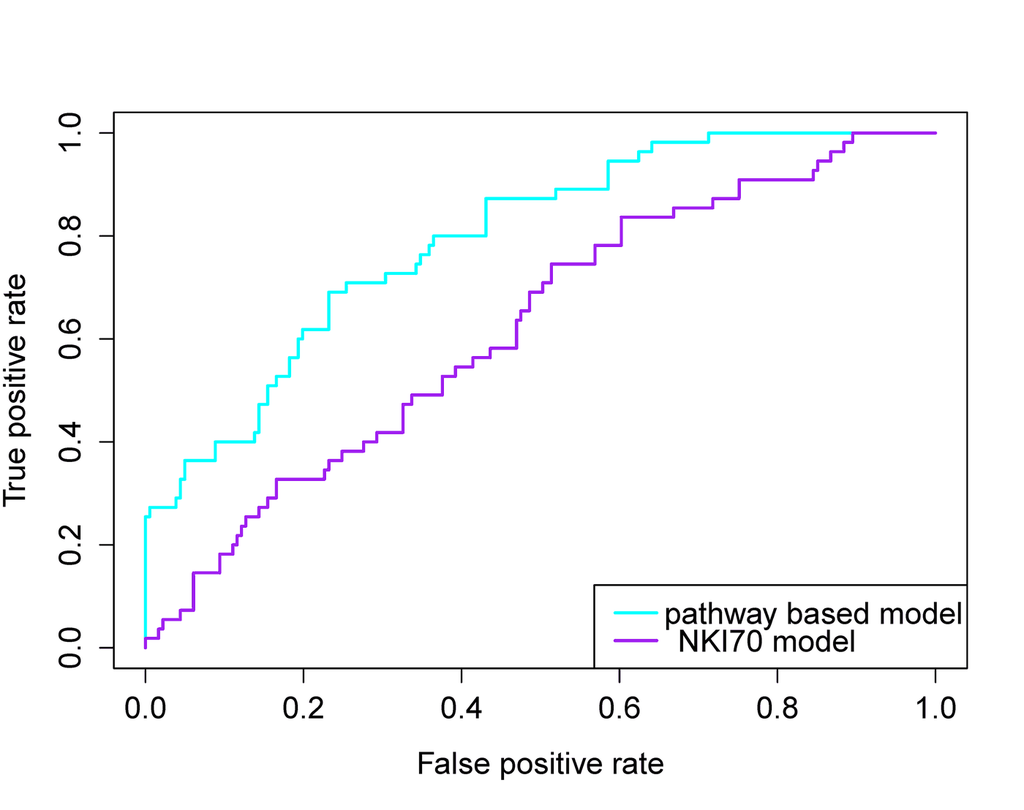

Our run

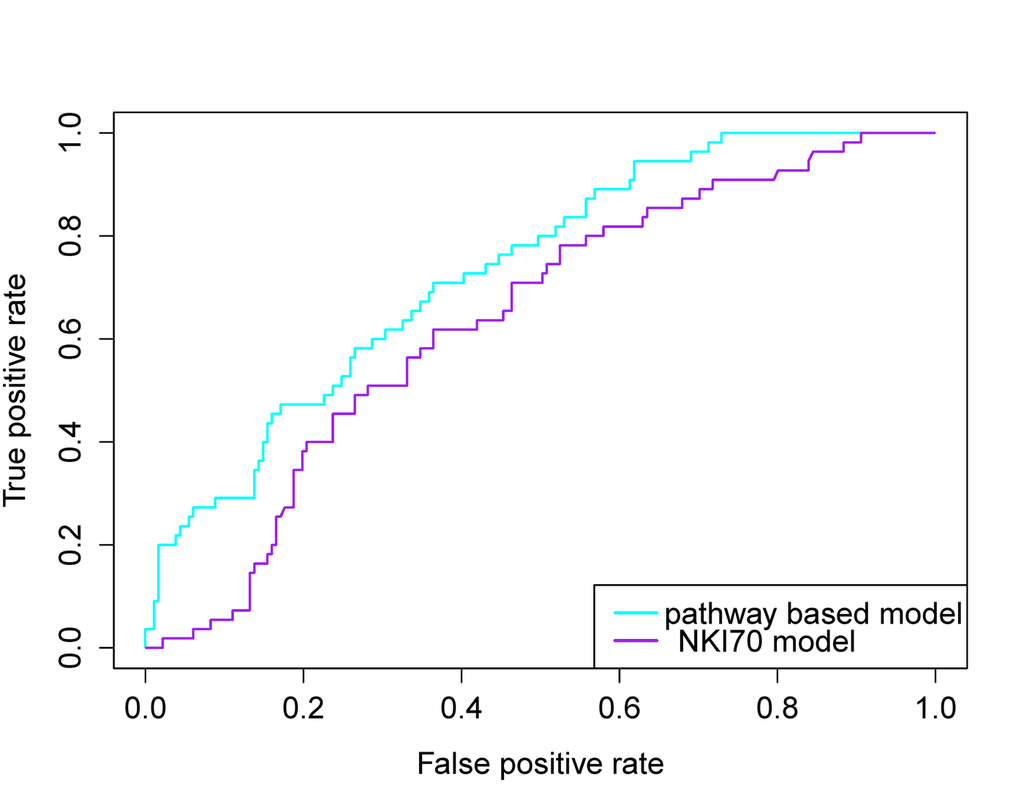

**Fig. S3 and text, NKI70 on the training set: log-rank p and AUC**

2 of 2 values, Agrees

**Fig. S3, ROC of NKI70 and the pathway-based model**

14.4% of curve pixels within 2 px (pass 90.0%, best control 14.5%), Inconclusive

The NKI70 curve is ours and agrees in number (figS3.nki70); the pathway-model curve follows our model, not the paper's; see fig4.values.

## Table 3

The 30 genes most often found in the genomic model's pathways, counted and weighted by hazard ratio.

Agrees

Table 3, genomic-model counts and weighted counts of the top 30 genes. 60 of 60 values.

| Value | Paper | Ours | Match |
| --- | --- | --- | --- |
| PRKACB count | 3 | 3 | yes |
| PRKACB weighted | 7.109452 | 7.109450431 | yes |
| PRKACG count | 3 | 3 | yes |
| PRKACG weighted | 7.109452 | 7.109450431 | yes |
| PRKCB count | 3 | 3 | yes |
| PRKCB weighted | 6.600318 | 6.600316495 | yes |
| PRKCA count | 3 | 3 | yes |
| PRKCA weighted | 6.600318 | 6.600316495 | yes |
| CALM1 count | 3 | 3 | yes |
| CALM1 weighted | 5.991523 | 5.991521106 | yes |
| CALM2 count | 3 | 3 | yes |
| CALM2 weighted | 5.991523 | 5.991521106 | yes |
| CALM3 count | 3 | 3 | yes |
| CALM3 weighted | 5.991523 | 5.991521106 | yes |
| GNAQ count | 3 | 3 | yes |
| GNAQ weighted | 5.991523 | 5.991521106 | yes |
| SRC count | 3 | 3 | yes |
| SRC weighted | 4.817049 | 4.817049232 | yes |
| GSK3B count | 2 | 2 | yes |
| GSK3B weighted | 4.615435 | 4.615432544 | yes |
| CDC25A count | 2 | 2 | yes |
| CDC25A weighted | 4.178799 | 4.178799341 | yes |
| CDK1 count | 2 | 2 | yes |
| CDK1 weighted | 4.178799 | 4.178799341 | yes |
| PRKAR2A count | 2 | 2 | yes |
| PRKAR2A weighted | 4.176796 | 4.176795889 | yes |
| PRKAR2B count | 2 | 2 | yes |
| PRKAR2B weighted | 4.176796 | 4.176795889 | yes |
| HRAS count | 2 | 2 | yes |
| HRAS weighted | 4.104297 | 4.104295155 | yes |
| MAP2K1 count | 2 | 2 | yes |
| MAP2K1 weighted | 4.104297 | 4.104295155 | yes |
| MAPK1 count | 2 | 2 | yes |
| MAPK1 weighted | 4.104297 | 4.104295155 | yes |
| MAPK3 count | 2 | 2 | yes |
| MAPK3 weighted | 4.104297 | 4.104295155 | yes |
| RAF1 count | 2 | 2 | yes |
| RAF1 weighted | 4.104297 | 4.104295155 | yes |
| MAP2K2 count | 2 | 2 | yes |
| MAP2K2 weighted | 4.104297 | 4.104295155 | yes |
| TP53 count | 3 | 3 | yes |
| TP53 weighted | 3.991545 | 3.99154366 | yes |
| GRB2 count | 2 | 2 | yes |
| GRB2 weighted | 3.667662 | 3.667661953 | yes |
| CYCSP35 count | 2 | 2 | yes |
| CYCSP35 weighted | 3.058867 | 3.058866564 | yes |
| PLCG1 count | 2 | 2 | yes |
| PLCG1 weighted | 3.058867 | 3.058866564 | yes |
| MAP3K1 count | 2 | 2 | yes |
| MAP3K1 weighted | 3.058867 | 3.058866564 | yes |
| E2F1 count | 2 | 2 | yes |
| E2F1 weighted | 2.952836 | 2.952835279 | yes |
| RB1 count | 2 | 2 | yes |
| RB1 weighted | 2.952836 | 2.952835279 | yes |
| CCND1 count | 2 | 2 | yes |
| CCND1 weighted | 2.952836 | 2.952835279 | yes |
| CDK4 count | 2 | 2 | yes |
| CDK4 weighted | 2.952836 | 2.952835279 | yes |
| CCNE1 count | 2 | 2 | yes |
| CCNE1 weighted | 2.952836 | 2.952835279 | yes |

**Table 3, genomic-model counts and weighted counts of the top 30 genes**

60 of 60 values, Agrees

## Every result

Every figure panel, table and number of the paper, with our value and the verdict computed from results.json.

| Result | Verdict | Measure | Why |
| --- | --- | --- | --- |
| Table 1, training set (Miller) | Agrees | 39 of 39 values; 6 slips in the paper left out |  |
| Table 1, test set 1 (Pawitan) | Agrees | 14 of 14 values |  |
| Table 1, test set 2 (Ivshina) | Partly agrees | 37 of 40 values | The size classes' boundaries are not given. Counting 50 mm tumours as over 50 gives the paper's 10 (strictly over 50: 6); under 10 mm gives 15 against the printed 14 with any boundary we tried. |
| Table 1, test set 3 (Desmedt) | Partly agrees | 29 of 30 values | The largest Desmedt tumour is 50 mm; the paper's one tumour over 50 mm is it, counted as over 50 (as for Ivshina; Miller's three 50 mm tumours are in no class). |
| Fig. 1A, PAM50 heatmap | Not attempted |  | The heatmap's gene scaling, palette and ordering are not given; its one testable number, the chi-square p of its two patient clusters against relapse, is item fig1.A.pam50_groups. |
| Fig. 1A, chi-square p of ER, PG, p53, grade and LN against relapse (Miller) | Agrees | 5 of 5 values |  |
| Fig. 1A and text, chi-square p of the two PAM50 clusters against relapse | Differs | 0 of 1 values | No clustering of the Miller tumours on the PAM50 genes we tried reaches the printed p (best 0.011 against 7.46e-5); the paper does not say how it clustered or which PAM50 genes it used (41 of 50 are o… |
| Fig. 1B to E and text, log-rank p of LN, grade, p53, size, ER and PG (Miller) | Agrees | 6 of 6 values |  |
| Fig. 1B, Kaplan-Meier by lymph node status | Agrees | 97.9% of curve pixels within 2 px (pass 90.0%, best control 78.7%) |  |
| Fig. 1C, Kaplan-Meier by grade | Agrees | 96.2% of curve pixels within 2 px (pass 90.0%, best control 77.6%) |  |
| Fig. 1D, Kaplan-Meier by p53 status | Agrees | 98.4% of curve pixels within 2 px (pass 90.0%, best control 79.7%) |  |
| Fig. 1E, Kaplan-Meier by tumour size | Agrees | 96.7% of curve pixels within 2 px (pass 90.0%, best control 77.1%) |  |
| Fig. 2, workflow of the model | Not attempted |  | A diagram of the four steps of the method; it is the structure of the package pdscox. |
| Fig. 3, heatmap of the 15 selected pathways | Not attempted |  | The heatmap's scaling, palette and ordering are not given; its testable numbers are in item fig3.values. |
| Fig. 3, chi-square p of ER, PG, p53, grade and LN against relapse (more digits) | Agrees | 5 of 5 values |  |
| Fig. 3 and text, PDS clusters against relapse and median-PDS correlation | Differs | 0 of 3 values | On our scores of the paper's 15 pathways the two clusters are not associated with relapse (p 0.23, printed 1.99e-6) and the median score hardly correlates with it (0.047, printed 0.17); on the pathway… |
| Table 2, pathway-based genomic model: pathways and coefficients | Partly agrees | 3 of 30 values | Our LASSO keeps 5 pathways, 3 of them the paper's (SRCRPTP, RARRXR, IL5); the paper keeps 15. The selection follows from the scores, and our scores of the paper's pathways are not the paper's (table2.… |
| Table 2, univariate Cox p of the 15 pathways on our scores | Partly agrees | 4 of 15 values | Our pathway scores are not the paper's: of the 15 pathways of Table 2, 4 have a univariate Cox p within one order of magnitude of the printed one on our scores, and VIP, LYSOSOME, AKAP13 and LINOLEIC … |
| Table 2, clinical model: features and coefficients | Partly agrees | 5 of 9 values | The same four features are selected; the coefficients differ by 0.0003 to 0.049. The penalty is the median of 250 random cross-validations (ours 7.32); its exact value depends on the folds, which the … |
| Table 2, univariate Cox p of LN, size, grade and p53 | Agrees | 4 of 4 values |  |
| Table 2 and text, combined model: pathways kept and clinical features | Partly agrees | 4 of 5 values | Lymph node and size are kept and grade and p53 are not, as in the paper; 4 of our 5 genomic pathways are kept (paper: 10 of 15). The pathway count follows from our genomic model (table2.genomic). |
| Fig. 4 and text, log-rank p and AUC of the genomic model on the four sets | Partly agrees | 1 of 8 values | The models are fitted on our pathway scores, which are not the paper's (table2.genomic_univariate): our genomic model keeps 5 pathways, not 15. It reaches Miller p 1.1e-7 and AUC 0.73 (printed 6.25e-1… |
| Fig. 4A, training set (Miller) | Partly agrees | 36.8% of curve pixels within 2 px (pass 90.0%, best control 33.6%) | The curves follow our model, not the paper's; see fig4.values. |
| Fig. 4B, test set 1 (Pawitan) | Partly agrees | 47.0% of curve pixels within 2 px (pass 90.0%, best control 43.1%) | The curves follow our model, not the paper's; see fig4.values. |
| Fig. 4C, test set 2 (Ivshina) | Partly agrees | 39.7% of curve pixels within 2 px (pass 90.0%, best control 35.1%) | The curves follow our model, not the paper's; see fig4.values. |
| Fig. 4D, test set 3 (Desmedt) | Inconclusive | 13.6% of curve pixels within 2 px (pass 90.0%, best control 24.8%) | The curves follow our model, not the paper's; see fig4.values. |
| Fig. 4E, ROC curves of the genomic model | Partly agrees | 10.0% of curve pixels within 2 px (pass 90.0%, best control 8.8%) | The curves follow our model, not the paper's; see fig4.values. |
| Fig. S1 and text, AUC falls as fewer pathways are kept | Differs | median AUC 1/2 0.715, 1/4 0.722, 1/8 0.712, 1/16 0.707; 1/2 against 1/4 t-test p 0.222; AUC range 0.661 to 0.794 (paper: decreasing, p < 0.05, 0.69 to 0.81) | With 1/2 to 1/16 of the pathways the median AUC stays at 0.71 to 0.72 (0.715, 0.722, 0.712, 0.707; 1/2 against 1/4: t-test p 0.22) instead of falling clearly. Our full model already keeps only 5 pathw… |
| Fig. 5 and text, log-rank p and AUC of the gene- and pathway-based models | Partly agrees | 2 of 16 values | The pathway models are fitted on our pathway scores, which are not the paper's (table2.genomic_univariate); the gene models on our gene-level expression, whose mapping and normalization may differ fro… |
| Fig. 5A, Miller gene-based model | Inconclusive | 72.3% of curve pixels within 2 px (pass 90.0%, best control 74.7%) | The curves follow our model, not the paper's; see fig5.values. |
| Fig. 5B, Miller pathway-based model | Inconclusive | 56.8% of curve pixels within 2 px (pass 90.0%, best control 57.3%) | The curves follow our model, not the paper's; see fig5.values. |
| Fig. 5C, Pawitan gene-based model | Partly agrees | 56.0% of curve pixels within 2 px (pass 90.0%, best control 49.7%) | The curves follow our model, not the paper's; see fig5.values. |
| Fig. 5D, Pawitan pathway-based model | Partly agrees | 55.9% of curve pixels within 2 px (pass 90.0%, best control 50.9%) | The curves follow our model, not the paper's; see fig5.values. |
| Fig. 5E, Ivshina gene-based model | Inconclusive | 15.0% of curve pixels within 2 px (pass 90.0%, best control 45.1%) | The curves follow our model, not the paper's; see fig5.values. |
| Fig. 5F, Ivshina pathway-based model | Partly agrees | 53.6% of curve pixels within 2 px (pass 90.0%, best control 52.6%) | The curves follow our model, not the paper's; see fig5.values. |
| Fig. 5G, Desmedt gene-based model | Differs | 0.7% of curve pixels within 2 px (pass 90.0%, best control 6.6%) | The curves follow our model, not the paper's; see fig5.values. |
| Fig. 5H, Desmedt pathway-based model | Differs | 0.9% of curve pixels within 2 px (pass 90.0%, best control 26.1%) | The curves follow our model, not the paper's; see fig5.values. |
| Text: pathway-based models beat gene-based models on all four sets | Differs | pathway-based better than gene-based (lower p and higher AUC) in 1 of 4 sets: pawitan | On our scores the pathway model beats the gene model on Pawitan only; on Miller it has the higher AUC but the higher p, on Ivshina the gene model wins, and on Desmedt neither model keeps a feature. Se… |
| Fig. S2: LOOCV, pathway-based above gene-based on all four sets (t-test p < 0.001) | Differs | LOOCV: pathway-based above gene-based with t-test p < 0.001 for both p and AUC in 2 of 4 sets | Leave-one-out without refitting puts the pathway model's AUC above the gene model's on Miller and Pawitan (t-test p < 1e-100; on Miller its p-values are the weaker) and below it on Ivshina; Desmedt ha… |
| Fig. S3 and text, NKI70 on the training set: log-rank p and AUC | Agrees | 2 of 2 values |  |
| Fig. S3, ROC of NKI70 and the pathway-based model | Inconclusive | 14.4% of curve pixels within 2 px (pass 90.0%, best control 14.5%) | The NKI70 curve is ours and agrees in number (figS3.nki70); the pathway-model curve follows our model, not the paper's; see fig4.values. |
| Fig. 6 and text, log-rank p and AUC of the genomic, combined and clinical models | Partly agrees | 6 of 12 values | The genomic and combined models are fitted on our pathway scores, which are not the paper's (table2.genomic_univariate). The clinical model matches on Miller (p 3.9e-11 against 2.2e-10, AUC 0.75 again… |
| Fig. 6A, Miller genomic model | Partly agrees | 37.6% of curve pixels within 2 px (pass 90.0%, best control 33.6%) | The curves follow our model, not the paper's; see fig6.values. |
| Fig. 6B, Ivshina genomic model | Partly agrees | 35.5% of curve pixels within 2 px (pass 90.0%, best control 32.3%) | The curves follow our model, not the paper's; see fig6.values. |
| Fig. 6C, Miller combined model | Partly agrees | 43.7% of curve pixels within 2 px (pass 90.0%, best control 38.0%) | The curves follow our model, not the paper's; see fig6.values. |
| Fig. 6D, Ivshina combined model | Inconclusive | 52.6% of curve pixels within 2 px (pass 90.0%, best control 52.6%) | The curves follow our model, not the paper's; see fig6.values. |
| Fig. 6E, Miller clinical model | Partly agrees | 69.1% of curve pixels within 2 px (pass 90.0%, best control 56.3%) | The curves follow our model, not the paper's; see fig6.values. |
| Fig. 6F, Ivshina clinical model | Inconclusive | 25.4% of curve pixels within 2 px (pass 90.0%, best control 29.1%) | The curves follow our model, not the paper's; see fig6.values. |
| Fig. 6G, ROC curves of the three models | Partly agrees | 25.1% of curve pixels within 2 px (pass 90.0%, best control 21.4%) | The curves follow our model, not the paper's; see fig6.values. |
| Text: combined beats genomic beats clinical, on Miller and Ivshina | Differs | combined > genomic > clinical by AUC, combined below genomic by p: miller no, ivshina yes | Combined beats genomic beats clinical on Ivshina; on Miller our genomic model (AUC 0.73) is below the clinical model (0.75), with 5 pathways instead of the paper's 15. See fig6.values. |
| Fig. S4: LOOCV, combined above pathway above clinical (t-test p < 0.001) | Differs | LOOCV: combined > pathway > clinical by AUC with t-test p < 0.001: miller no, ivshina yes | As text.fig6_claim: the order holds on Ivshina; on Miller the pathway model's leave-one-out AUC (0.73) is below the clinical model's (0.75). |
| Table 3, genomic-model counts and weighted counts of the top 30 genes | Agrees | 60 of 60 values |  |
| Table 3, combined-model counts and weighted counts, and the 265 shared genes | Not attempted |  | The combined model's hazard ratios are not printed, and its gene counts are higher than its 10 starred pathways can give, so the columns cannot be rebuilt; our combined model differs as well (table2.c… |
| Discussion: genes covered by the 403 pathways and expressed | Differs | 403 pathways: 403; over 4500 genes in them: 5555; over 3200 expressed (mean log2 > 7): 1502; U133A over 14,000 genes: 12502; over 10,000 expressed: 3936 | 5,555 genes are in the 403 sets (paper: over 4,500) and all 403 are scored. The paper's 'over 3,200 expressed' and 'over 14,000 genes, over 10,000 expressed' on U133A depend on its mapping and express… |
| Claims recomputed from the paper's own tables and figure titles | Agrees | 9 of 9 claims come back from the paper's own tables and figure titles |  |
| Text: the main claims on our run (test p < 0.0005, average test AUC 0.68, combined 3 orders better) | Differs | 0 of 3 values | Follows from fig4.values and fig6.values: Desmedt's p is 0.69, the average test AUC is 0.63, and on Ivshina the combined model's p (2.0e-9) is 2.98 orders below the genomic model's (1.9e-6), just shor… |
| R package pdscox and its tutorial | Agrees | R package pdscox: R CMD check OK; tests 17 passed, 0 failed, 0 skipped; tutorial rendering equals the committed TUTORIAL.md (figures by name) |  |

The paper's main claim does not hold on our run: the pathway model is weaker than printed and does not carry to Desmedt. Adding clinical features does help it on both sets (AUC 0.81 against 0.73 on Miller, 0.69 against 0.67 on Ivshina). Ivshina is not an independent test set: 232 of its 249 arrays are Miller's.

## What came back

**The pipeline**

pathifier scores, the penalized Cox model with 250 cross-validations, the prognostic index and its cutoffs, the clinical, combined, gene-based and NKI70 models, as the R package pdscox.

**The patients**

Table 1's counts for all four data sets, once Miller's clinical data were found in breastCancerUPP (GEO has none); left over are a swapped PgR row and rounding in the paper, the size-class boundaries, and one Ivshina tumour under 10 mm (15 against 14).

**Fig. 1**

11 of its 12 printed p-values (the chi-square and log-rank tests of the clinical factors; not the PAM50 clusters), and the four Kaplan-Meier panels within 2 px (96 to 98% of the published curve pixels).

**The clinical model**

The same four features (lymph node, size, grade, p53) with coefficients within 0.05 of Table 2, and the four univariate p-values as printed.

**Table 3**

The genomic model's top 30 genes with their counts and weights, 60 of 60 fields, from the paper's own pathways and hazard ratios.

**NKI70**

Its log-rank p and AUC on the training set, as printed in Fig. S3.

## What stayed buried

- The paper's pathway scores: on ours, 11 of its 15 selected pathways have univariate p-values more than ten times larger (VIP, LYSOSOME, AKAP13 and LINOLEIC ACID at p 0.5 to 0.8 instead of 2e-6 to 4e-3). On five of them, other seeds, no normalization, no gene filters, no stability option or linear input did not bring them back.
- So our genomic model keeps 5 pathways (3 of the paper's) instead of 15, and the test sets come out weaker than printed: Desmedt p 0.69 against 3.73e-4.
- Desmedt's own models: cross-validation keeps no gene and no pathway; the paper's p 5.12e-36 and AUC 0.92 need a penalty far below the cross-validated one.
- The PAM50 clusters of Fig. 1A and the pathway clusters of Fig. 3: no clustering we tried reaches the printed p-values (best 0.011 against 7.46e-5, and 7.4e-4 against 1.99e-6).
- Fig. S1: with fewer pathways the AUC hardly falls (median 0.715 to 0.707).

The paper's main claim does not hold on our run: the pathway model is weaker than printed and does not carry to Desmedt. Adding clinical features does help it on both sets (AUC 0.81 against 0.73 on Miller, 0.69 against 0.67 on Ivshina). Ivshina is not an independent test set: 232 of its 249 arrays are Miller's.

## What we matched

What we compared, and how.

**Tables and numbers**

Typed from the paper; counts as printed, percentages within one point, model p-values within one order of magnitude, AUCs within 0.03.

**Kaplan-Meier and ROC panels**

Our curves drawn on each published panel's pixel grid, placed through its tick marks and scored within 2 px against controls (shifted and swapped curves).

**Claims**

Each written as a comparison; the 9 that rest on the paper's own numbers hold there.